# Topical siRNA therapy of diabetic-like wound healing

Eva Neuhoferova & Marek Kindermann et al

2024-06-28

### Introduction

This report shows source data, statistical code and outputs of *regression models* in a *Bayesian framework*.

Specifically, analysis for Figure 5A, B, C, D and Figure 3B is shown.

All analyses were done using [R sofware](https://www.r-project.org/) in [RStudio](https://www.rstudio.com/) interface.

### Software version

```r
### Clear R environment:
rm(list=ls())
R.version
```

```
##                _
## platform       x86_64-w64-mingw32
## arch           x86_64
## os             mingw32
## system         x86_64, mingw32
## status
## major          4
## minor          1.2
## year           2021
## month          11
## day            01
## svn rev        81115
## language       R
## version.string R version 4.1.2 (2021-11-01)
## nickname       Bird Hippie
```

```r
rstudioapi::versionInfo()$version
```

```
## [1] '2024.9.1.394'
```

### Libraries

```r
### Uploading R packages:
library(here)            # file referencing
library(dplyr)           # for data manipulation
library(ggplot2)         # plot data
library(brms)            # Bayesian model fit
library(bayesplot)       # plot posterior distributions
library(loo)             # leave-one-out cross-validation
library(tidyr)           # data manipulation
library(tibble)          # related to tidyr
library(ggdist)          # plot posterior: stat_halfeye(), stat_slab()
library(wesanderson)     # set posterior palette: wes_palette()
library(marginaleffects) # get the final effect size
```

```r
### Uploading R packages:
citation("here")            # file referencing
```

```
##
##
##   Kirill Müller (2020). here: A Simpler Way to Find Your Files. R
##   package version 1.0.1. https://CRAN.R-project.org/package=here
##
## A BibTeX entry for LaTeX users is
##
##   @Manual{,
##     title = {here: A Simpler Way to Find Your Files},
##     author = {Kirill Müller},
##     year = {2020},
##     note = {R package version 1.0.1},
##     url = {https://CRAN.R-project.org/package=here},
##   }
```

```r
citation("dplyr")           # for data manipulation
```

```
##
##
##   Hadley Wickham, Romain François, Lionel Henry, Kirill Müller and
##   Davis Vaughan (2023). dplyr: A Grammar of Data Manipulation. R
##   package version 1.1.2. https://CRAN.R-project.org/package=dplyr
##
## A BibTeX entry for LaTeX users is
##
##   @Manual{,
##     title = {dplyr: A Grammar of Data Manipulation},
##     author = {Hadley Wickham and Romain François and Lionel Henry and Kirill Müller and Davis Vaughan},
##     year = {2023},
##     note = {R package version 1.1.2},
##     url = {https://CRAN.R-project.org/package=dplyr},
##   }
```

```r
citation("ggplot2")         # plot data
```

```
##
##
##   H. Wickham. ggplot2: Elegant Graphics for Data Analysis.
##   Springer-Verlag New York, 2016.
##
## A BibTeX entry for LaTeX users is
##
##   @Book{,
##     author = {Hadley Wickham},
##     title = {ggplot2: Elegant Graphics for Data Analysis},
##     publisher = {Springer-Verlag New York},
##     year = {2016},
##     isbn = {978-3-319-24277-4},
##     url = {https://ggplot2.tidyverse.org},
##   }
```

```r
citation("brms")            # Bayesian model fit
```

```
##
##
##   Paul-Christian Bürkner (2017). brms: An R Package for Bayesian
##   Multilevel Models Using Stan. Journal of Statistical Software, 80(1),
##   1-28. doi:10.18637/jss.v080.i01
##
##   Paul-Christian Bürkner (2018). Advanced Bayesian Multilevel Modeling
##   with the R Package brms. The R Journal, 10(1), 395-411.
##   doi:10.32614/RJ-2018-017
##
##   Paul-Christian Bürkner (2021). Bayesian Item Response Modeling in R
##   with brms and Stan. Journal of Statistical Software, 100(5), 1-54.
##   doi:10.18637/jss.v100.i05
##
## To see these entries in BibTeX format, use 'print(<citation>,
## bibtex=TRUE)', 'toBibtex(.)', or set
## 'options(citation.bibtex.max=999)'.
```

```r
citation("bayesplot")       # plot posterior distributions
```

```
##
##
## Gabry J, Mahr T (2022). "bayesplot: Plotting for Bayesian Models." R
## package version 1.9.0, <URL: https://mc-stan.org/bayesplot/>.
##
##
## Gabry J, Simpson D, Vehtari A, Betancourt M, Gelman A (2019).
## "Visualization in Bayesian workflow." _J. R. Stat. Soc. A_, *182*,
## 389-402. doi: 10.1111/rssa.12378 (URL:
## https://doi.org/10.1111/rssa.12378).
##
## To see these entries in BibTeX format, use 'print(<citation>,
## bibtex=TRUE)', 'toBibtex(.)', or set
## 'options(citation.bibtex.max=999)'.
```

```r
citation("loo")             # leave-one-out cross-validation
```

```
##
##
## Vehtari A, Gabry J, Magnusson M, Yao Y, Bürkner P, Paananen T, Gelman A
## (2024). "loo: Efficient leave-one-out cross-validation and WAIC for
## Bayesian models." R package version 2.8.0, <URL:
## https://mc-stan.org/loo/>.
##
##
## Vehtari A, Gelman A, Gabry J (2017). "Practical Bayesian model
## evaluation using leave-one-out cross-validation and WAIC." _Statistics
## and Computing_, *27*, 1413-1432. doi: 10.1007/s11222-016-9696-4 (URL:
## https://doi.org/10.1007/s11222-016-9696-4).
##
##
## Yao Y, Vehtari A, Simpson D, Gelman A (2017). "Using stacking to
## average Bayesian predictive distributions." _Bayesian Analysis_. doi:
## 10.1214/17-BA1091 (URL: https://doi.org/10.1214/17-BA1091).
##
## To see these entries in BibTeX format, use 'print(<citation>,
## bibtex=TRUE)', 'toBibtex(.)', or set
## 'options(citation.bibtex.max=999)'.
```

```r
citation("tidyr")           # data manipulation
```

```
##
##
##   Hadley Wickham, Davis Vaughan and Maximilian Girlich (2023). tidyr:
##   Tidy Messy Data. R package version 1.3.0.
##   https://CRAN.R-project.org/package=tidyr
##
## A BibTeX entry for LaTeX users is
##
##   @Manual{,
##     title = {tidyr: Tidy Messy Data},
##     author = {Hadley Wickham and Davis Vaughan and Maximilian Girlich},
##     year = {2023},
##     note = {R package version 1.3.0},
##     url = {https://CRAN.R-project.org/package=tidyr},
##   }
```

```r
citation("tibble")          # related to tidyr
```

```
##
##
##   Kirill Müller and Hadley Wickham (2023). tibble: Simple Data Frames.
##   R package version 3.2.1. https://CRAN.R-project.org/package=tibble
##
## A BibTeX entry for LaTeX users is
##
##   @Manual{,
##     title = {tibble: Simple Data Frames},
##     author = {Kirill Müller and Hadley Wickham},
##     year = {2023},
##     note = {R package version 3.2.1},
##     url = {https://CRAN.R-project.org/package=tibble},
##   }
```

```r
citation("ggdist")          # plot posterior: stat_halfeye(), stat_slab()
```

```
##
## Kay M (2023). _ggdist: Visualizations of Distributions and
## Uncertainty_. doi: 10.5281/zenodo.3879620 (URL:
## https://doi.org/10.5281/zenodo.3879620), R package version 3.3.0, <URL:
## https://mjskay.github.io/ggdist/>.
##
## A BibTeX entry for LaTeX users is
##
##   @Manual{,
##     title = {{ggdist}: Visualizations of Distributions and Uncertainty},
##     author = {Matthew Kay},
##     year = {2023},
##     note = {R package version 3.3.0},
##     url = {https://mjskay.github.io/ggdist/},
##     doi = {10.5281/zenodo.3879620},
##   }
```

```r
citation("wesanderson")     # set posterior palette: wes_palette()
```

```
##
##
##   Karthik Ram and Hadley Wickham (2018). wesanderson: A Wes Anderson
##   Palette Generator. R package version 0.3.6.
##   https://CRAN.R-project.org/package=wesanderson
##
## A BibTeX entry for LaTeX users is
##
##   @Manual{,
##     title = {wesanderson: A Wes Anderson Palette Generator},
##     author = {Karthik Ram and Hadley Wickham},
##     year = {2018},
##     note = {R package version 0.3.6},
##     url = {https://CRAN.R-project.org/package=wesanderson},
##   }
```

```r
citation("marginaleffects") # get the final effect size
```

```
##
##
##   Vincent Arel-Bundock (2023). marginaleffects: Predictions,
##   Comparisons, Slopes, Marginal Means, and Hypothesis Tests. R package
##   version 0.16.0. https://CRAN.R-project.org/package=marginaleffects
##
## A BibTeX entry for LaTeX users is
##
##   @Manual{,
##     title = {marginaleffects: Predictions, Comparisons, Slopes, Marginal Means, and Hypothesis
## Tests},
##     author = {Vincent Arel-Bundock},
##     year = {2023},
##     note = {R package version 0.16.0},
##     url = {https://CRAN.R-project.org/package=marginaleffects},
##   }
```

### WOUND HEALING - Figure 5A, B and D

The regression model is applied to the time-to-event data, which are shown in *Figure 5A, B* in the manuscript. The resulting effect size is shown in *Figure 5D* utilizing full posterior distributions.

The *Weibull model* allows us to assume a monotonically increasing hazard function *h_W (t)*. In other words, the chance of wound closure increases with time. Results of the Weibull regression model in *Figure 5A-B* (smooth curves) are shown in terms of the survival function *S_W(t)*, which describes the probability that wound closure has not occurred by the elapsed time.

For the definitions of *h_W (t)* and *S_W (t)* see the manuscript. For a complete discussion of statistical analysis, see the *Supporting Information*, section *Statistical analysis*.

I found the text from Solomon Kurz as extremely helpful - see chapter 11.5 in “Statistical rethinking with brms, ggplot2, and the tidyverse: Second edition version 0.4.0; A Solomon Kurz; 2023-01-26; Bonus: Survival analysis”. (https://bookdown.org/content/4857/)

### Load data:

File *Figure_5.txt* from the GitHub repository contains the source data (see link https://github.com/KindermannMarek/Topical-siRNA-therapy-1).

*treat*, *group_id*, *status* should be coded as **factors**  
*day_of_scar_formation*, *censoring_status* are **numerical variables**

```r
### Load data
rm(list=ls())
### Upload (!Use your own path to the data table! Load file *Figure_5.txt* from the repository.)
file.exists("c:/Users/KindermannM/Documents/OneDrive_hotmail_gmail/4_biomedical_center/R2/1_uochb/Projects/HPMA_patent/data/Figure_4.txt")
```

```
## [1] TRUE
```

```r
### Upload (!Use your own path to the data table! Load file *Figure_5.txt* from the repository.)
data <- read.delim("c:/Users/KindermannM/Documents/OneDrive_hotmail_gmail/4_biomedical_center/R2/1_uochb/Projects/HPMA_patent/data/Figure_4.txt")
attach(data)

treat <- as.factor(treat)
group_ID <- as.factor(group_ID)
status <- as.factor(status)
day_of_scar_formation <- as.numeric(day_of_scar_formation)
censoring_status <- as.numeric(censoring_status)

data
```

```
##    group_ID glyc_pre glyc_post diff day_of_scar_formation   status treat
## 1         1      8.4       8.7  0.3                    13  healthy     C
## 2         1      7.7      19.3 11.6                    14 diabetic     B
## 3         1      5.2      19.1 13.9                    19 diabetic     A
## 4         1      6.7      20.3 13.6                    19 diabetic     D
## 5         1      6.8      16.4  9.6                    20 diabetic     E
## 6         2      6.4       5.6 -0.8                    13  healthy     C
## 7         2      7.8      14.5  6.7                    14 diabetic     B
## 8         2      8.4      10.7  2.3                    20 diabetic     A
## 9         2      6.5      10.7  4.2                    19 diabetic     D
## 10        2      5.9       9.4  3.5                    20 diabetic     E
## 11        3      7.8       8.3  0.5                    12  healthy     C
## 12        3      6.8      23.2 16.4                    13 diabetic     B
## 13        3      7.2      22.8 15.6                    19 diabetic     A
## 14        3      7.6      22.4 14.8                    19 diabetic     D
```

[output cut: 17 more lines]

### BM1

The weakly informative priors for the coefficients *𝛽* are centered around 0, reflecting the conservative assumption that the difference between the reference treatment and the others can be positive, negative or equal to zero. Standard deviation (sd) of this prior was estimated as sd = 2 × standard deviation(day_of_scar_formation); prior(normal(0, 6)).

See section *Statistical analysis* in manuscript for the formal model notation.

```r
### Bayesian model
set.seed = 17

data$treat <- as.factor(data$treat)
data$treat  <- relevel(data$treat, ref = "A")

bform_1 <- bf(day_of_scar_formation ~ 1 + treat)
prior_1 <- c(prior(normal(0, 6), class = b))

fit_1 <- brm(bform_1,
            data = data,
            family = brmsfamily("weibull"),
            prior = prior_1,
            warmup = 2000,
            iter = 5000,
            chains = 4,
            cores = 4,
            control = list(adapt_delta = 0.95, max_treedepth = 15))
            fit_1 <- add_criterion(fit_1, "loo")
```

### BM1.3

Try to include the grouping variable *group_ID* to improve the model.

```r
### Bayesian model
set.seed = 17

data$treat <- as.factor(data$treat)
data$treat  <- relevel(data$treat, ref = "A")

bform_1.3 <- bf(day_of_scar_formation ~ 1 + treat + (1 | group_ID))
prior_1.3 <- c(prior(normal(0, 2), class = b))

fit_1.3 <- brm(bform_1.3,
            data = data,
            family = brmsfamily("weibull"),
            prior = prior_1.3,
            warmup = 2000,
            iter = 5000,
            chains = 4,
            cores = 4,
            control = list(adapt_delta = 0.95, max_treedepth = 15))
            fit_1.3 <- add_criterion(fit_1.3, "loo")
```

The model diagnostic revealed 204 divergent transitions after warmup. Therefore, we utilize BM1 for the final analysis.

```r
###  Summary of a fitted model
summary(fit_1)
```

```
##  Family: weibull
##   Links: mu = log; shape = identity
## Formula: day_of_scar_formation ~ 1 + treat
##    Data: data (Number of observations: 15)
##   Draws: 4 chains, each with iter = 5000; warmup = 2000; thin = 1;
##          total post-warmup draws = 12000
##
## Population-Level Effects:
##           Estimate Est.Error l-95% CI u-95% CI Rhat Bulk_ESS Tail_ESS
## Intercept     2.96      0.02     2.92     3.00 1.00     4088     4052
## treatB       -0.35      0.03    -0.40    -0.29 1.00     4472     4651
## treatC       -0.42      0.03    -0.47    -0.37 1.00     4885     5228
## treatD       -0.03      0.03    -0.08     0.03 1.00     4875     5063
## treatE        0.01      0.03    -0.04     0.07 1.00     5032     4624
##
## Family Specific Parameters:
##       Estimate Est.Error l-95% CI u-95% CI Rhat Bulk_ESS Tail_ESS
## shape    38.16     10.20    20.80    60.20 1.00     3716     5569
##
## Draws were sampled using sampling(NUTS). For each parameter, Bulk_ESS
## and Tail_ESS are effective sample size measures, and Rhat is the potential
## scale reduction factor on split chains (at convergence, Rhat = 1).
```

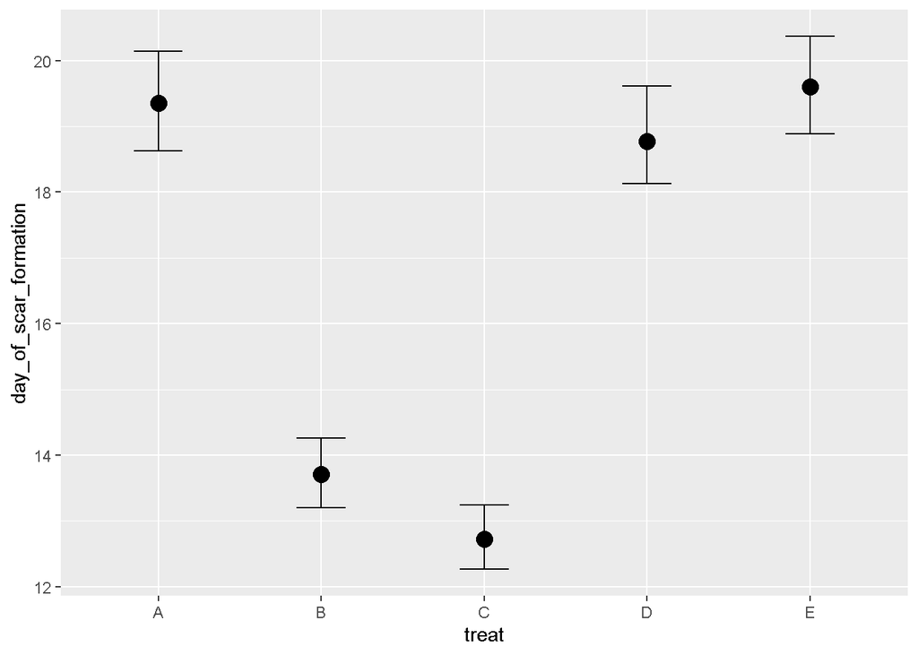

```r
### Display conditional effects
conditional_effects(fit_1)
```

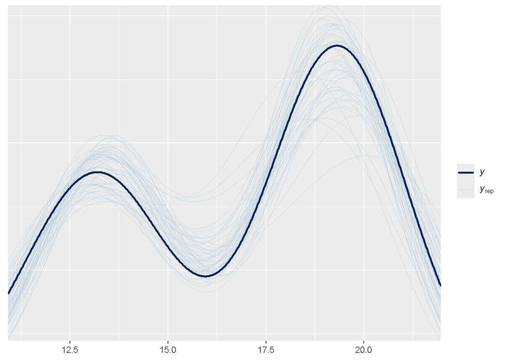

```r
### Distribution of outcome vs. newly simulated data distribution
### (dark line should be close to light lines)
pp_check(fit_1, ndraws = 50)
```

```r
### Bayesian version of R-squared for regression model
bayes_R2(fit_1)
```

```
##    Estimate  Est.Error      Q2.5     Q97.5
## R2 0.970846 0.01014754 0.9439273 0.9803977
```

```r
### "Leave-one-out extreme value diagnostic"
loo(fit_1, 'moment_match = TRUE')
```

```
##
## Computed from 12000 by 15 log-likelihood matrix.
##
##          Estimate  SE
## elpd_loo    -14.7 2.4
## p_loo         4.6 0.9
## looic        29.4 4.8
## ------
## MCSE of elpd_loo is NA.
## MCSE and ESS estimates assume MCMC draws (r_eff in [0.3, 0.9]).
##
## Pareto k diagnostic values:
##                          Count Pct.    Min. ESS
## (-Inf, 0.7]   (good)     14    93.3%   1899
##    (0.7, 1]   (bad)       1     6.7%   <NA>
##    (1, Inf)   (very bad)  0     0.0%   <NA>
## See help('pareto-k-diagnostic') for details.
```

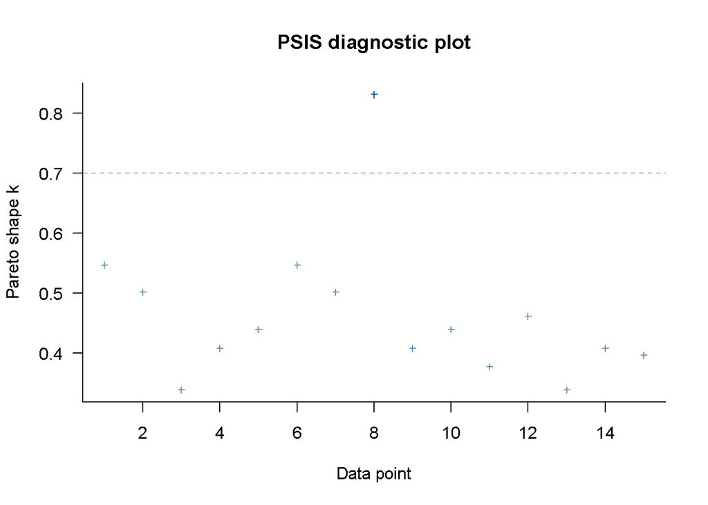

```r
plot(loo(fit_1, 'moment_match = TRUE'))
```

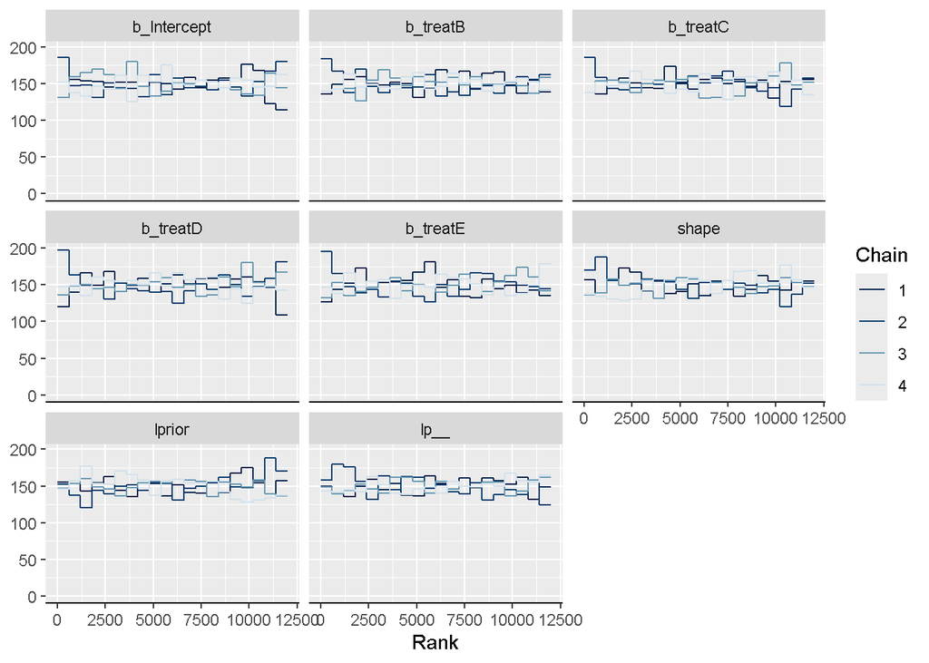

```r
### Trace rank plot: these histograms should be reasonable uniform, with no
### chain spiking above or below the others.
mcmc_rank_overlay(fit_1)
```

```r
### Check whether the priors were informative:
### Is the posterior standard deviation greater than 10% of the prior
### standard deviation?
bayestestR::check_prior(fit_1)
```

```
##     Parameter Prior_Quality
## 1 b_Intercept uninformative
## 2    b_treatB uninformative
## 3    b_treatC uninformative
## 4    b_treatD uninformative
## 5    b_treatE uninformative
```

### BM1.1

Prior sensitivity analysis for BM1: Try to check the more narrower prior.

```r
### Bayesian model
set.seed = 17
bform_1.1 <- bf(day_of_scar_formation ~ 1 + treat)
prior_1.1 <- c(prior(normal(0, 1), class = b))

fit_1.1 <- brm(bform_1.1,
            data = data,
            family = brmsfamily("weibull"),
            prior = prior_1.1,
            warmup = 2000,
            iter = 5000,
            chains = 4,
            cores = 4,
            control = list(adapt_delta = 0.95, max_treedepth = 15))
            fit_1.1 <- add_criterion(fit_1.1, "loo")
```

```r
###  Summary of a fitted model
summary(fit_1.1)
```

```
##  Family: weibull
##   Links: mu = log; shape = identity
## Formula: day_of_scar_formation ~ 1 + treat
##    Data: data (Number of observations: 15)
##   Draws: 4 chains, each with iter = 5000; warmup = 2000; thin = 1;
##          total post-warmup draws = 12000
##
## Population-Level Effects:
##           Estimate Est.Error l-95% CI u-95% CI Rhat Bulk_ESS Tail_ESS
## Intercept     2.96      0.02     2.92     3.00 1.00     4062     4371
## treatB       -0.34      0.03    -0.39    -0.29 1.00     4993     5399
## treatC       -0.42      0.03    -0.47    -0.37 1.00     4696     5440
## treatD       -0.03      0.03    -0.08     0.03 1.00     4693     5165
## treatE        0.01      0.03    -0.04     0.07 1.00     5290     5595
##
## Family Specific Parameters:
##       Estimate Est.Error l-95% CI u-95% CI Rhat Bulk_ESS Tail_ESS
## shape    38.37     10.12    21.11    60.17 1.00     4130     6162
##
## Draws were sampled using sampling(NUTS). For each parameter, Bulk_ESS
## and Tail_ESS are effective sample size measures, and Rhat is the potential
## scale reduction factor on split chains (at convergence, Rhat = 1).
```

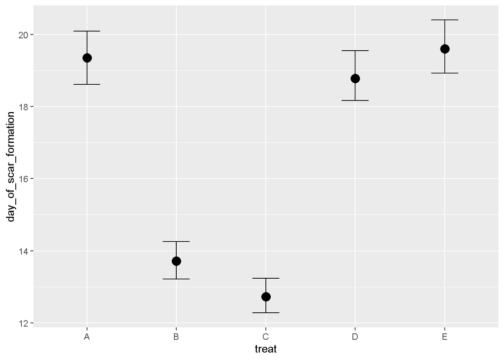

```r
### Display conditional effects
conditional_effects(fit_1.1)
```

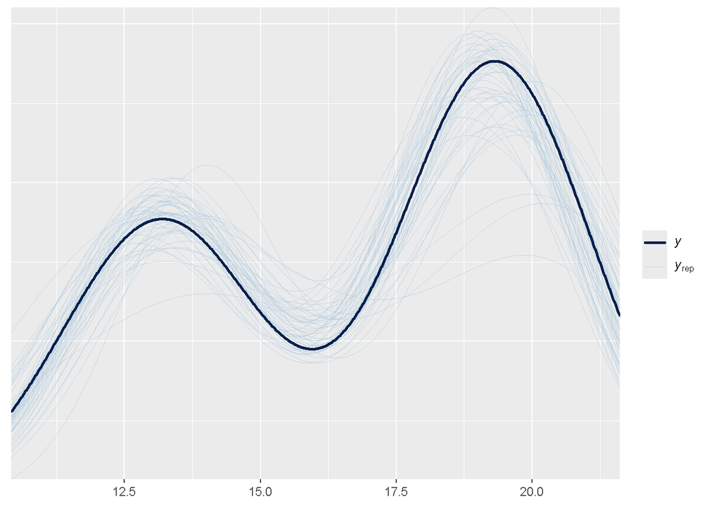

```r
### Distribution of outcome vs. newly simulated data distribution
### (dark line should be close to light lines)
pp_check(fit_1.1, ndraws = 50)
```

```r
### Bayesian version of R-squared for regression model
bayes_R2(fit_1.1)
```

```
##     Estimate   Est.Error      Q2.5     Q97.5
## R2 0.9711726 0.009667707 0.9451279 0.9804932
```

```r
### "Leave-one-out extreme value diagnostic"
loo(fit_1.1, 'moment_match = TRUE')
```

```
##
## Computed from 12000 by 15 log-likelihood matrix.
##
##          Estimate  SE
## elpd_loo    -14.4 2.4
## p_loo         4.3 0.8
## looic        28.7 4.8
## ------
## MCSE of elpd_loo is NA.
## MCSE and ESS estimates assume MCMC draws (r_eff in [0.3, 1.0]).
##
## Pareto k diagnostic values:
##                          Count Pct.    Min. ESS
## (-Inf, 0.7]   (good)     14    93.3%   2134
##    (0.7, 1]   (bad)       1     6.7%   <NA>
##    (1, Inf)   (very bad)  0     0.0%   <NA>
## See help('pareto-k-diagnostic') for details.
```

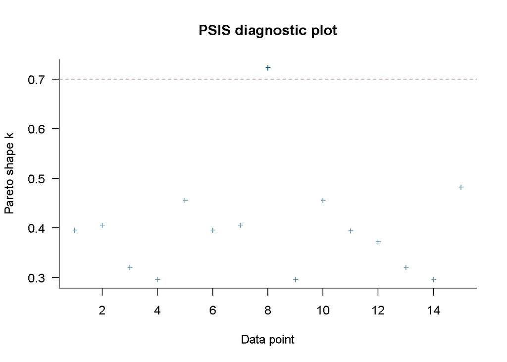

```r
plot(loo(fit_1.1, 'moment_match = TRUE'))
```

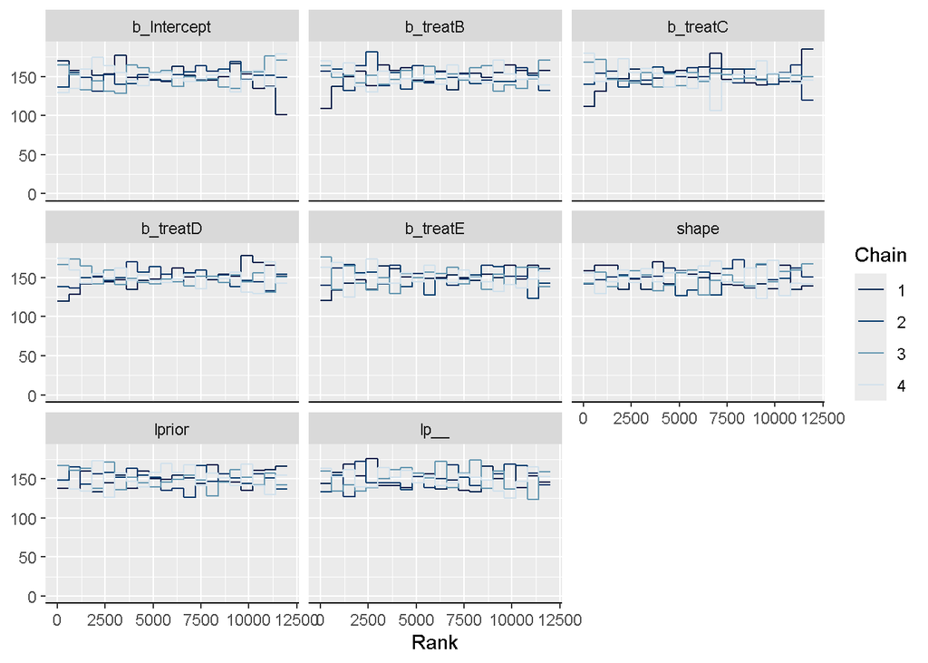

```r
### Trace rank plot: these histograms should be reasonable uniform, with no
### chain spiking above or below the others.
mcmc_rank_overlay(fit_1.1)
```

```r
### Check whether the priors were informative:
### Is the posterior standard deviation greater than 10% of the prior
### standard deviation?
bayestestR::check_prior(fit_1.1)
```

```
##     Parameter Prior_Quality
## 1 b_Intercept uninformative
## 2    b_treatB uninformative
## 3    b_treatC uninformative
## 4    b_treatD uninformative
## 5    b_treatE uninformative
```

### BM1.2

Prior sensitivity analysis for BM1: Try to check the more wider prior.

```r
### Bayesian model
set.seed = 17
bform_1.2 <- bf(day_of_scar_formation ~ 1 + treat)
prior_1.2 <- c(prior(normal(0, 12), class = b))

fit_1.2 <- brm(bform_1.2,
            data = data,
            family = brmsfamily("weibull"),
            prior = prior_1.2,
            warmup = 2000,
            iter = 5000,
            chains = 4,
            cores = 4,
            control = list(adapt_delta = 0.95, max_treedepth = 15))
            fit_1.2 <- add_criterion(fit_1.2, "loo")
```

Both sensitivity analysis seem to be fine (there is no substantial change in the estimated parameters). The results are consistent with the proposed priors.

```r
###  Summary of a fitted model
summary(fit_1.2)
```

```
##  Family: weibull
##   Links: mu = log; shape = identity
## Formula: day_of_scar_formation ~ 1 + treat
##    Data: data (Number of observations: 15)
##   Draws: 4 chains, each with iter = 5000; warmup = 2000; thin = 1;
##          total post-warmup draws = 12000
##
## Population-Level Effects:
##           Estimate Est.Error l-95% CI u-95% CI Rhat Bulk_ESS Tail_ESS
## Intercept     2.96      0.02     2.93     3.00 1.00     4080     4437
## treatB       -0.34      0.03    -0.40    -0.29 1.00     4682     4650
## treatC       -0.42      0.03    -0.47    -0.37 1.00     4965     4389
## treatD       -0.03      0.03    -0.08     0.03 1.00     4807     4600
## treatE        0.01      0.03    -0.04     0.07 1.00     4815     4507
##
## Family Specific Parameters:
##       Estimate Est.Error l-95% CI u-95% CI Rhat Bulk_ESS Tail_ESS
## shape    38.07     10.10    20.83    60.02 1.00     3714     5720
##
## Draws were sampled using sampling(NUTS). For each parameter, Bulk_ESS
## and Tail_ESS are effective sample size measures, and Rhat is the potential
## scale reduction factor on split chains (at convergence, Rhat = 1).
```

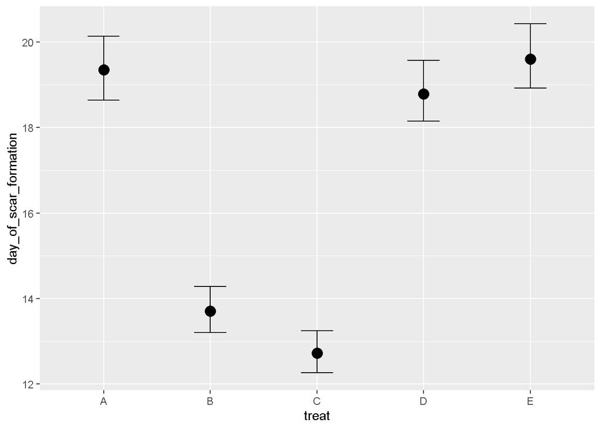

```r
### Display conditional effects
conditional_effects(fit_1.2)
```

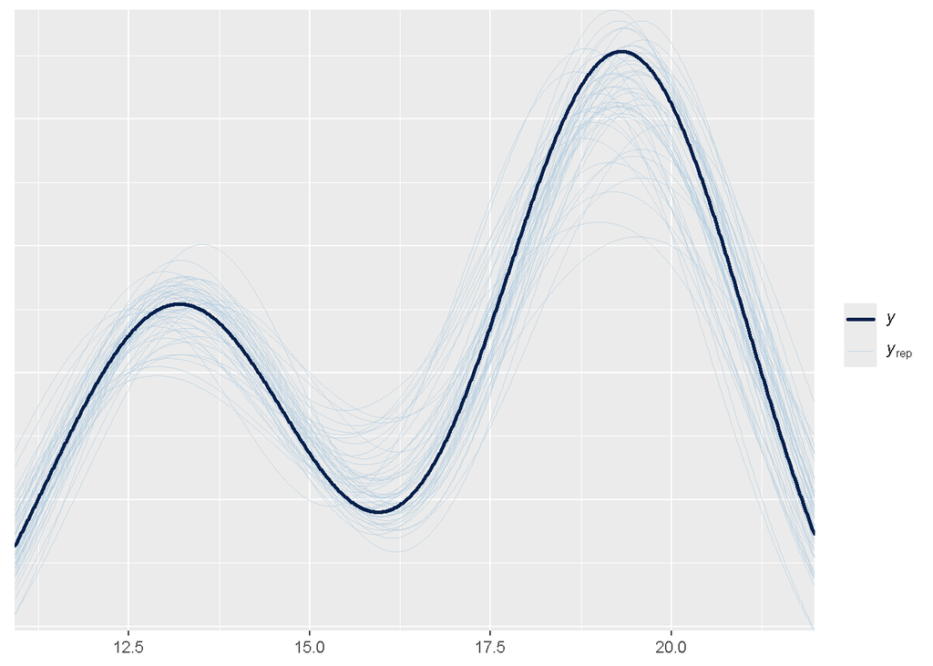

```r
### Distribution of outcome vs. newly simulated data distribution
### (dark line should be close to light lines)
pp_check(fit_1.2, ndraws = 50)
```

```r
### Bayesian version of R-squared for regression model
bayes_R2(fit_1.2)
```

```
##     Estimate  Est.Error      Q2.5     Q97.5
## R2 0.9708995 0.01030021 0.9432885 0.9805142
```

```r
### "Leave-one-out extreme value diagnostic"
loo(fit_1.2, 'moment_match = TRUE')
```

```
##
## Computed from 12000 by 15 log-likelihood matrix.
##
##          Estimate  SE
## elpd_loo    -14.5 2.4
## p_loo         4.4 0.9
## looic        29.1 4.9
## ------
## MCSE of elpd_loo is NA.
## MCSE and ESS estimates assume MCMC draws (r_eff in [0.3, 0.9]).
##
## Pareto k diagnostic values:
##                          Count Pct.    Min. ESS
## (-Inf, 0.7]   (good)     14    93.3%   2361
##    (0.7, 1]   (bad)       1     6.7%   <NA>
##    (1, Inf)   (very bad)  0     0.0%   <NA>
## See help('pareto-k-diagnostic') for details.
```

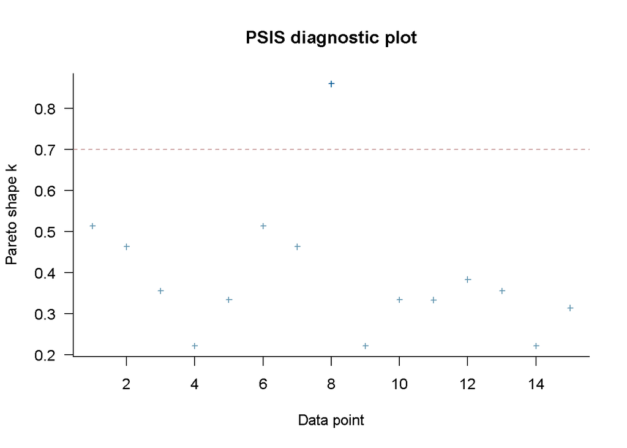

```r
plot(loo(fit_1.2, 'moment_match = TRUE'))
```

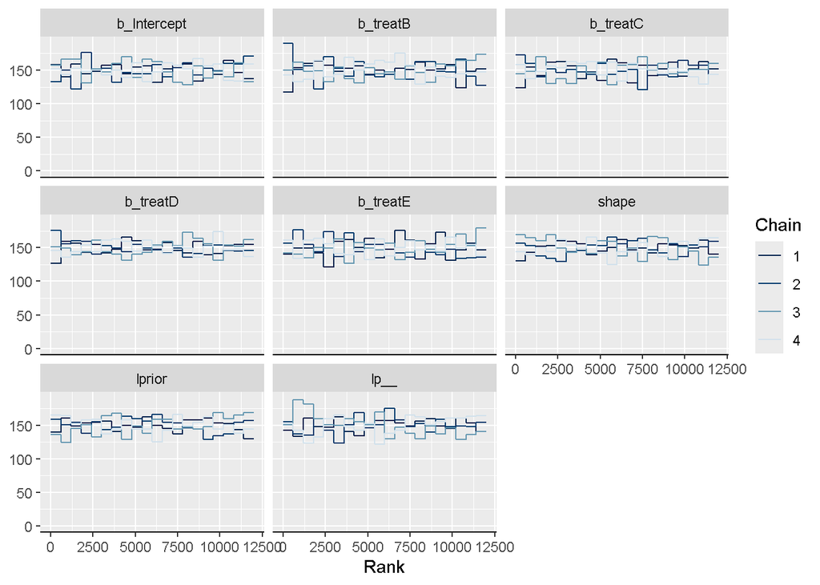

```r
### Trace rank plot: these histograms should be reasonable uniform, with no
### chain spiking above or below the others.
mcmc_rank_overlay(fit_1.2)
```

```r
### Check whether the priors were informative:
### Is the posterior standard deviation greater than 10% of the prior
### standard deviation?
bayestestR::check_prior(fit_1.2)
```

```
##     Parameter Prior_Quality
## 1 b_Intercept uninformative
## 2    b_treatB uninformative
## 3    b_treatC uninformative
## 4    b_treatD uninformative
## 5    b_treatE uninformative
```

### BM1 - Get survival and hazard function

```r
### See chapter 11.5 in Statistical rethinking with brms, ggplot2, and the
### tidyverse: Second edition version 0.4.0
### A Solomon Kurz; 2023-01-26
### Bonus: Survival analysis

### Back-transformation of estimated β parameters into the λ metric
### See equation (4) in manuscript
est_shape <- 37.85
est_scaleA <- exp(fixef(fit_1)[1, 1]) / gamma(1 + 1/est_shape)
est_scaleB <- exp(fixef(fit_1)[2, 1]) / gamma(1 + 1/est_shape)
est_scaleC <- exp(fixef(fit_1)[3, 1]) / gamma(1 + 1/est_shape)
est_scaleD <- exp(fixef(fit_1)[4, 1]) / gamma(1 + 1/est_shape)
est_scaleE <- exp(fixef(fit_1)[5, 1]) / gamma(1 + 1/est_shape)

ll_scaleA <- exp(fixef(fit_1)[1, 3]) / gamma(1 + 1/est_shape)
ll_scaleB <- exp(fixef(fit_1)[2, 3]) / gamma(1 + 1/est_shape)
ll_scaleC <- exp(fixef(fit_1)[3, 3]) / gamma(1 + 1/est_shape)
ll_scaleD <- exp(fixef(fit_1)[4, 3]) / gamma(1 + 1/est_shape)
ll_scaleE <- exp(fixef(fit_1)[5, 3]) / gamma(1 + 1/est_shape)

hh_scaleA <- exp(fixef(fit_1)[1, 4]) / gamma(1 + 1/est_shape)
hh_scaleB <- exp(fixef(fit_1)[2, 4]) / gamma(1 + 1/est_shape)
hh_scaleC <- exp(fixef(fit_1)[3, 4]) / gamma(1 + 1/est_shape)
hh_scaleD <- exp(fixef(fit_1)[4, 4]) / gamma(1 + 1/est_shape)
hh_scaleE <- exp(fixef(fit_1)[5, 4]) / gamma(1 + 1/est_shape)

### Get survival functions
### See equation (2) in manuscript
est <-
  data.frame(days = seq(0, 30, 0.001)) %>%
  mutate(est_SA = exp(-(days/est_scaleA)^est_shape)) %>%
  mutate(est_SB = exp(-(days/est_scaleB)^est_shape)) %>%
  mutate(est_SC = exp(-(days/est_scaleC)^est_shape)) %>%
  mutate(est_SD = exp(-(days/est_scaleD)^est_shape)) %>%
  mutate(est_SE = exp(-(days/est_scaleE)^est_shape))

ll <-
  data.frame(days = seq(0, 30, 0.001)) %>%
  mutate(ll_SA = exp(-(days/ll_scaleA)^est_shape)) %>%
  mutate(ll_SB = exp(-(days/ll_scaleB)^est_shape)) %>%
  mutate(ll_SC = exp(-(days/ll_scaleC)^est_shape)) %>%
  mutate(ll_SD = exp(-(days/ll_scaleD)^est_shape)) %>%
  mutate(ll_SE = exp(-(days/ll_scaleE)^est_shape))

hh <-
  data.frame(days = seq(0, 30, 0.001)) %>%
  mutate(hh_SA = exp(-(days/hh_scaleA)^est_shape)) %>%
  mutate(hh_SB = exp(-(days/hh_scaleB)^est_shape)) %>%
  mutate(hh_SC = exp(-(days/hh_scaleC)^est_shape)) %>%
  mutate(hh_SD = exp(-(days/hh_scaleD)^est_shape)) %>%
  mutate(hh_SE = exp(-(days/hh_scaleE)^est_shape))

### Get hazard functions
### See equation (3) in manuscript
est_hazard <-
  data.frame(days = seq(0, 20, 0.001)) %>%
  mutate(est_SA = (est_shape/est_scaleA) * (days/est_scaleA)^(est_shape - 1)) %>%
  mutate(est_SA = est_SA / max(est_SA)) %>%
  mutate(est_SB = (est_shape/est_scaleB) * (days/est_scaleB)^(est_shape - 1)) %>%
  mutate(est_SB = est_SB / max(est_SB)) %>%
  mutate(est_SC = (est_shape/est_scaleC) * (days/est_scaleC)^(est_shape - 1)) %>%
  mutate(est_SC = est_SC / max(est_SC)) %>%
  mutate(est_SD = (est_shape/est_scaleD) * (days/est_scaleD)^(est_shape - 1)) %>%
  mutate(est_SD = est_SD / max(est_SD)) %>%
  mutate(est_SE = (est_shape/est_scaleE) * (days/est_scaleE)^(est_shape - 1)) %>%
  mutate(est_SE = est_SE / max(est_SE))
```

### BM1 - Plot Bayesian posteriors showing the effect size (Figure 5D):

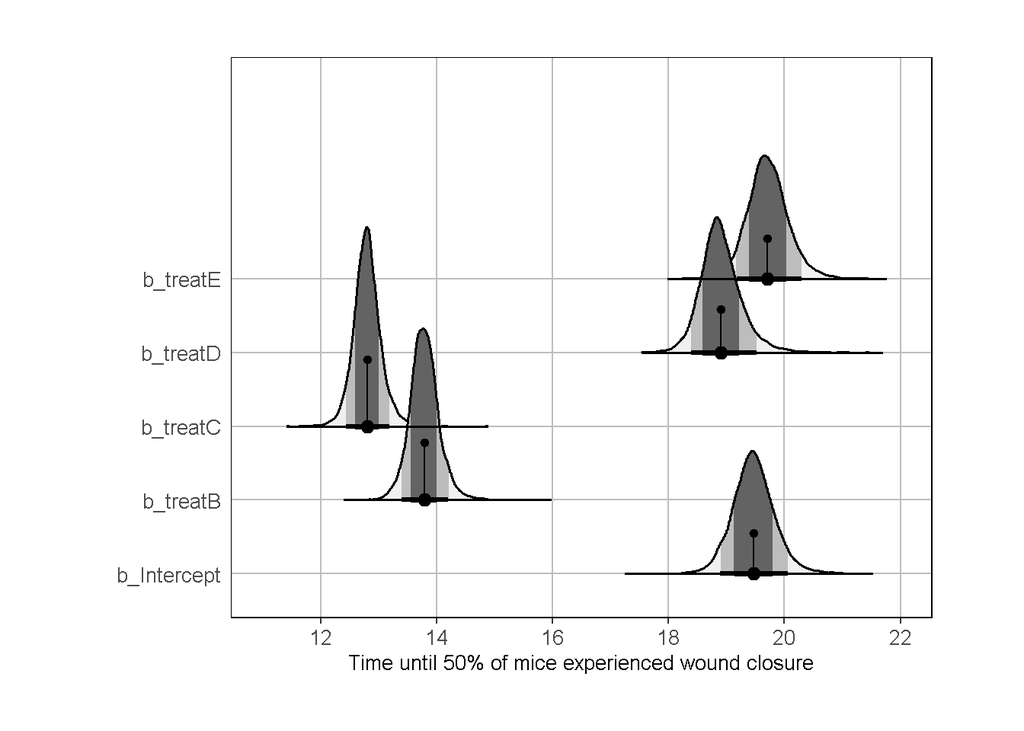

```r
### Plot the full posterior distributions
post <-
  as_draws_df(fit_1)  %>%
  pivot_longer(starts_with("b_")) %>%
  group_by(.draw)  %>%
  mutate(value2 = value + value[name == "b_Intercept"]) %>%
    mutate(value2 = case_when(
           value2 == value2[name == "b_Intercept"] ~ value[name == "b_Intercept"],
           TRUE ~ value2  # Keep other values unchanged
  )) %>%
  mutate(days = qweibull(p = .5, shape, scale = exp(value2) / gamma( 1 + 1/shape))) %>%
  mutate(days_diff = days - days[name == "b_Intercept" ])

(g1 <-
  post %>%
  ggplot(aes(x = days, y = name)) +
  stat_halfeye(aes(fill = after_stat(level)),    # area under curve colors
               point_interval = mean_qi,         # circle = mean + quantile intervals
               .width = c(0.67, .89, 1),         # areas under curve
               slab_color = "#000000",           # posterior curve color
               slab_linewidth = 0.7,
               height = 3) +
               stat_spike(at = c(mean)) +
  scale_fill_brewer(type = "seq",                # collor pallete - area under curve
                    palette = "Greys",
                    direction = 1,
                    aesthetics = "fill") +
  scale_colour_manual(values = c("#000000")) +   # posterior curve color (must be here)
  labs(x="Time until 50% of mice experienced wound closure") +
  labs(y="") +
  scale_x_continuous(limits = c(11, 22),
                     breaks = (c(10, 12, 14, 16, 18, 20, 22))) +
  theme(axis.ticks.y = element_blank()) +
  theme(legend.position="none", plot.title = element_text(size=10),
  aspect.ratio = 0.8,
  plot.margin = margin(1, 1, 1, 1, "cm"),
  axis.text=element_text(size=10),
  axis.title=element_text(size=10),
  plot.background = element_rect(fill='transparent', color=NA),
  panel.border = element_rect(colour = "black", fill=NA, size=0.5),
  panel.grid.major = element_line(color = "grey", size = 0.5),
  panel.background = element_rect(fill = "white", colour = "white"),
  legend.background = element_rect(fill='transparent'))
)
```

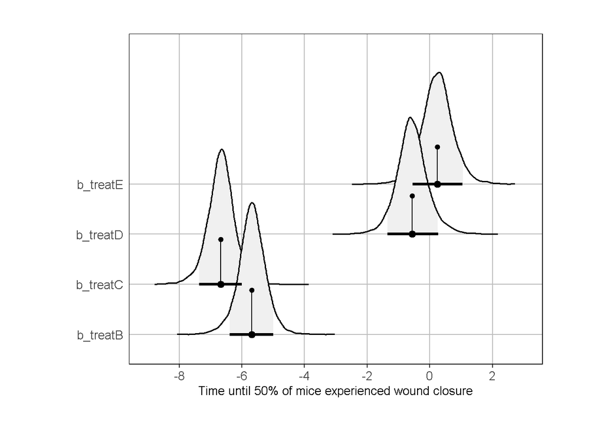

```r
(g2 <-
  post %>%
    filter(name != "b_Intercept") %>%
  ggplot(aes(x = days_diff, y = name)) +
  stat_halfeye(aes(fill = after_stat(level)),    # area under curve colors
               point_interval = mean_qi,         # circle = mean + quantile intervals
               .width = c(.89),         # areas under curve
               slab_color = "#000000",           # posterior curve color
               slab_linewidth = 0.7,
               height = 3) +
               stat_spike(at = c(mean)) +
  scale_fill_brewer(type = "seq",                # collor pallete - area under curve
                    palette = "Greys",
                    direction = 1,
                    aesthetics = "fill") +
  scale_colour_manual(values = c("#000000")) +   # posterior curve color (must be here)
  labs(x="Time until 50% of mice experienced wound closure") +
  labs(y="") +
  scale_x_continuous(limits = c(-9, 3),
                     breaks = (c(-8, -6, -4, -2, 0, 2)))  +
  theme(axis.ticks.y = element_blank()) +
  theme(legend.position="none", plot.title = element_text(size=10),
  aspect.ratio = 0.8,
  plot.margin = margin(1, 1, 1, 1, "cm"),
  axis.text=element_text(size=10),
  axis.title=element_text(size=10),
  plot.background = element_rect(fill='transparent', color=NA),
  panel.border = element_rect(colour = "black", fill=NA, size=0.5),
  panel.grid.major = element_line(color = "grey", size = 0.5),
  panel.background = element_rect(fill = "white", colour = "white"),
  legend.background = element_rect(fill='transparent'))
)
```

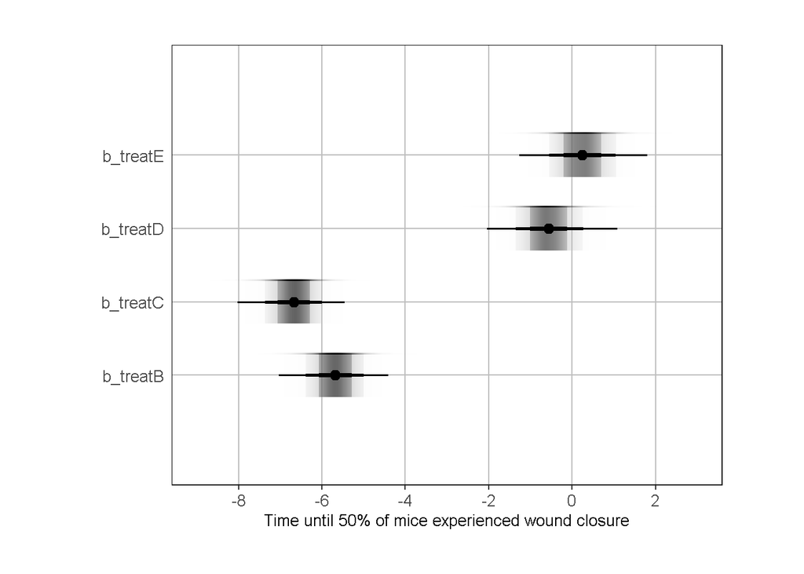

```r
(g3 <-
  post %>%
  filter(name != "b_Intercept") %>%
  ggplot(aes(x = days_diff, y = name)) +
  stat_gradientinterval(aes(fill = after_stat(level)),    # area under curve colors
               point_interval = mean_qi,         # circle = mean + quantile intervals
               .width = c(0.67, .89, 0.99),         # areas under curve
               slab_color = "#000000",           # posterior curve color
               slab_linewidth = 0.7,
               height = 3,
               scale = 0.2) +
  scale_fill_brewer(type = "seq",                # collor pallete - area under curve
                    palette = "Greys",
                    direction = 1,
                    aesthetics = "fill") +
  scale_colour_manual(values = c("#000000")) +   # posterior curve color (must be here)
  labs(x="Time until 50% of mice experienced wound closure") +
  labs(y="") +
  scale_x_continuous(limits = c(-9, 3),
                     breaks = (c(-8, -6, -4, -2, 0, 2)))  +
  theme(axis.ticks.y = element_blank()) +
  theme(legend.position="none", plot.title = element_text(size=10),
  aspect.ratio = 0.8,
  plot.margin = margin(1, 1, 1, 1, "cm"),
  axis.text=element_text(size=10),
  axis.title=element_text(size=10),
  plot.background = element_rect(fill='transparent', color=NA),
  panel.border = element_rect(colour = "black", fill=NA, size=0.5),
  panel.grid.major = element_line(color = "grey", size = 0.5),
  panel.background = element_rect(fill = "white", colour = "white"),
  legend.background = element_rect(fill='transparent'))
)
```

### GLUCOSE LEVEL - Figure 5C

Data were taken from “wound healing” dataset (file *Figure_5.txt* from the GitHub repository (see link https://github.com/KindermannMarek/Topical-siRNA-therapy-1).

Glucose data:

```r
#create animal ID
data <- data.frame(data, seq(1, 15, 1))
data <- rename(data, animal_ID = seq.1..15..1.)

#crete new dataframe
data2 <- data.frame(data$glyc_pre, data$glyc_post, data$group_ID, data$animal_ID, data$status)
data2 <-
  data2 %>%
  pivot_longer(starts_with("data.glyc")) %>%
  rename(group_ID = data.group_ID,
         animal_ID = data.animal_ID) %>%
  filter(data.status != "healthy")


data2_check <-
  data2 %>%
  filter(name != "data.glyc_post")
```

### BM2

```r
set.seed = 17

data2$name <- as.factor(data2$name)
data2$name <- relevel(data2$name, ref = "data.glyc_pre")

data2$group_ID <- as.factor(data2$group_ID)
data2$animal_ID <- as.factor(data2$animal_ID)
data2$data.status <- as.factor(data2$data.status)

data2$value  <- as.numeric(data2$value)

bform_2 <- bf(value ~ 1 + name)
prior_2 <- c(prior(normal(0, 12), class = b))

fit_2 <- brm(bform_2,
            data = data2,
            family = brmsfamily("lognormal"),
            prior = prior_2,
            warmup = 2000,
            iter = 5000,
            chains = 4,
            cores = 4,
            control = list(adapt_delta = 0.95, max_treedepth = 15))
            fit_2 <- add_criterion(fit_2, "loo")

summary(fit_2)
```

```
##  Family: lognormal
##   Links: mu = identity; sigma = identity
## Formula: value ~ 1 + name
##    Data: data2 (Number of observations: 24)
##   Draws: 4 chains, each with iter = 5000; warmup = 2000; thin = 1;
##          total post-warmup draws = 12000
##
## Population-Level Effects:
##                    Estimate Est.Error l-95% CI u-95% CI Rhat Bulk_ESS Tail_ESS
## Intercept              1.92      0.08     1.76     2.08 1.00     9617     7338
## namedata.glyc_post     0.90      0.11     0.68     1.11 1.00    10202     7007
##
## Family Specific Parameters:
##       Estimate Est.Error l-95% CI u-95% CI Rhat Bulk_ESS Tail_ESS
## sigma     0.27      0.04     0.20     0.37 1.00     8383     7882
##
## Draws were sampled using sampling(NUTS). For each parameter, Bulk_ESS
## and Tail_ESS are effective sample size measures, and Rhat is the potential
## scale reduction factor on split chains (at convergence, Rhat = 1).
```

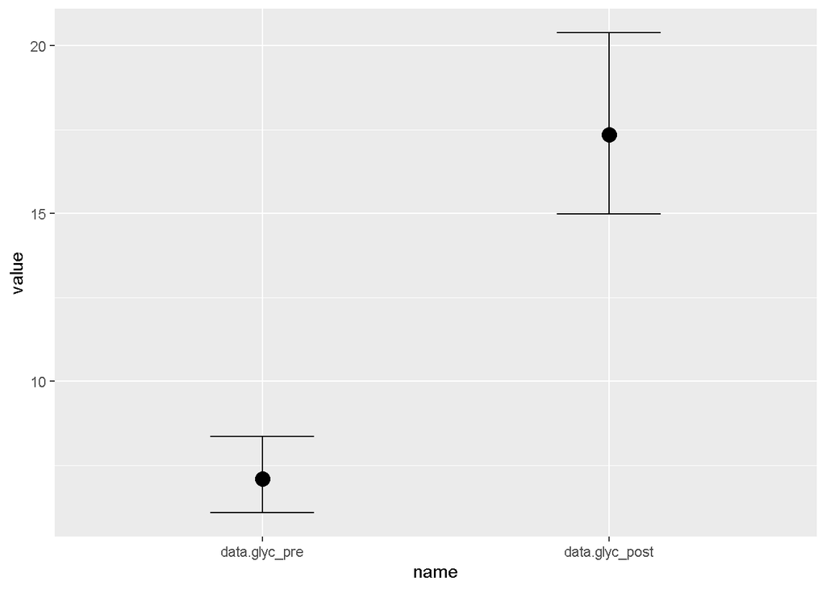

```r
conditional_effects(fit_2)
```

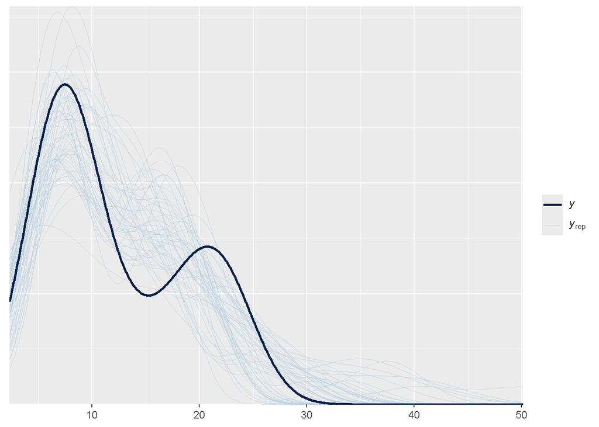

```r
pp_check(fit_2, ndraws = 50)
```

```r
bayes_R2(fit_2)
```

```
##     Estimate  Est.Error      Q2.5     Q97.5
## R2 0.6692639 0.06894986 0.5015034 0.7609932
```

```r
loo(fit_2, 'moment_match = TRUE')
```

```
##
## Computed from 12000 by 24 log-likelihood matrix.
##
##          Estimate  SE
## elpd_loo    -60.0 4.7
## p_loo         2.8 0.9
## looic       119.9 9.4
## ------
## MCSE of elpd_loo is 0.0.
## MCSE and ESS estimates assume MCMC draws (r_eff in [0.6, 0.9]).
##
## All Pareto k estimates are good (k < 0.7).
## See help('pareto-k-diagnostic') for details.
```

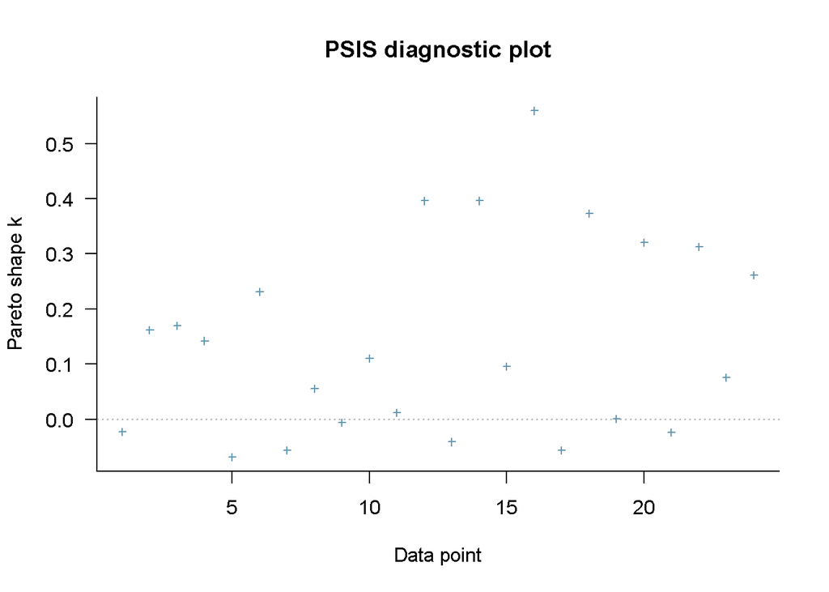

```r
plot(loo(fit_2, 'moment_match = TRUE'))
```

Include info about *animal_ID* (repeated measurements). It is good to note that it does not make sense to incorporate the *group_ID* to this model (the animals were divided in three groups based on the reached glucose level - the factor *group_ID* was created artificially - assignment of *group_ID*).

## BM2.1

```r
fit_2.1 <- update(fit_2, value ~ 1 + name + (1 | animal_ID),
                  newdata = data2)
```

```
## The desired updates require recompiling the model
```

```r
summary(fit_2.1)
```

```
##  Family: lognormal
##   Links: mu = identity; sigma = identity
## Formula: value ~ name + (1 | animal_ID)
##    Data: data2 (Number of observations: 24)
##   Draws: 4 chains, each with iter = 5000; warmup = 2000; thin = 1;
##          total post-warmup draws = 12000
##
## Group-Level Effects:
## ~animal_ID (Number of levels: 12)
##               Estimate Est.Error l-95% CI u-95% CI Rhat Bulk_ESS Tail_ESS
## sd(Intercept)     0.10      0.07     0.00     0.27 1.00     4157     5644
##
## Population-Level Effects:
##                    Estimate Est.Error l-95% CI u-95% CI Rhat Bulk_ESS Tail_ESS
## Intercept              1.92      0.08     1.76     2.09 1.00    10451     7202
## namedata.glyc_post     0.90      0.11     0.69     1.11 1.00    12882     8079
##
## Family Specific Parameters:
##       Estimate Est.Error l-95% CI u-95% CI Rhat Bulk_ESS Tail_ESS
## sigma     0.26      0.05     0.18     0.36 1.00     8413     7928
##
## Draws were sampled using sampling(NUTS). For each parameter, Bulk_ESS
## and Tail_ESS are effective sample size measures, and Rhat is the potential
## scale reduction factor on split chains (at convergence, Rhat = 1).
```

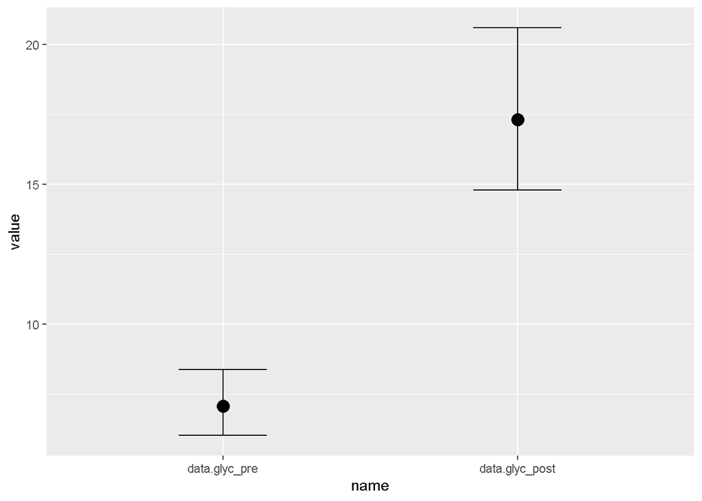

```r
conditional_effects(fit_2.1)
```

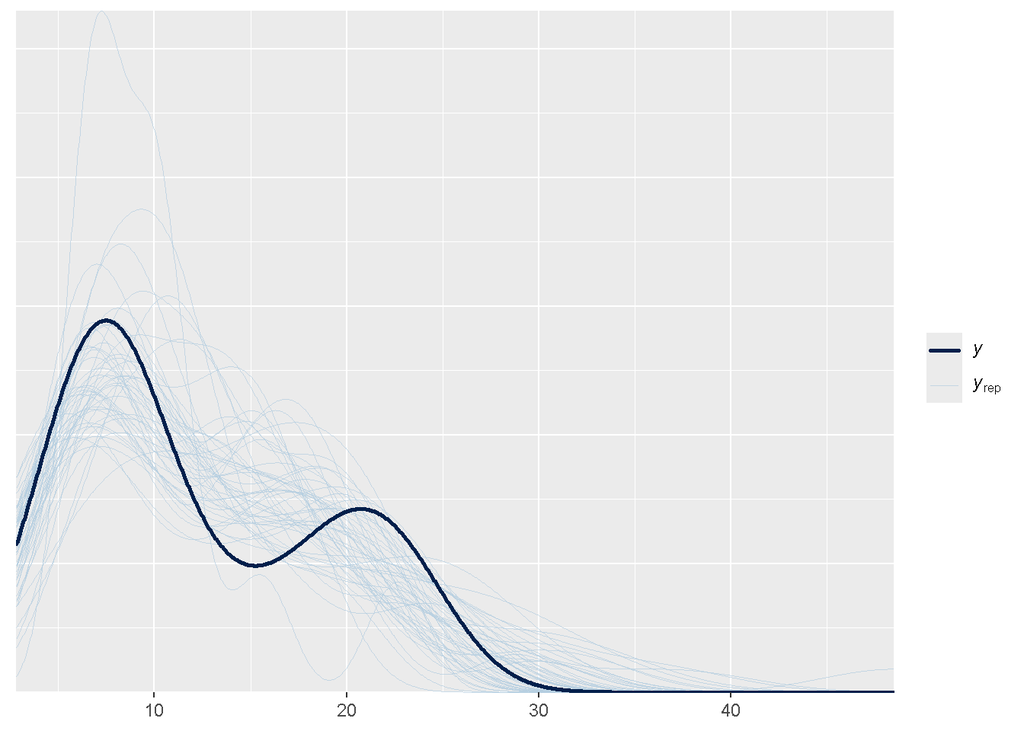

```r
pp_check(fit_2.1, ndraws = 50)
```

```r
bayes_R2(fit_2.1)
```

```
##     Estimate  Est.Error      Q2.5     Q97.5
## R2 0.7109772 0.07812068 0.5321148 0.8433286
```

```r
loo(fit_2.1, 'moment_match = TRUE')
```

```
##
## Computed from 12000 by 24 log-likelihood matrix.
##
##          Estimate  SE
## elpd_loo    -60.7 4.5
## p_loo         5.4 1.3
## looic       121.4 8.9
## ------
## MCSE of elpd_loo is NA.
## MCSE and ESS estimates assume MCMC draws (r_eff in [0.6, 1.2]).
##
## Pareto k diagnostic values:
##                          Count Pct.    Min. ESS
## (-Inf, 0.7]   (good)     23    95.8%   923
##    (0.7, 1]   (bad)       1     4.2%   <NA>
##    (1, Inf)   (very bad)  0     0.0%   <NA>
## See help('pareto-k-diagnostic') for details.
```

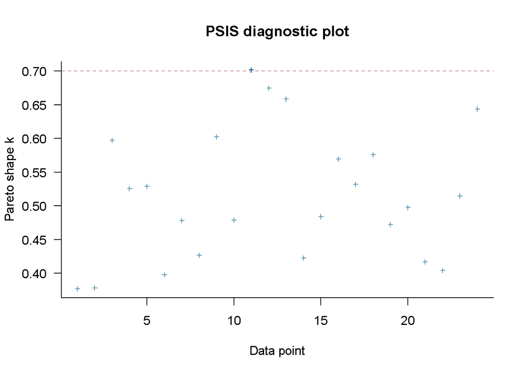

```r
plot(loo(fit_2.1, 'moment_match = TRUE'))
```

```r
loo(fit_2, fit_2.1)
```

```
## Output of model 'fit_2':
##
## Computed from 12000 by 24 log-likelihood matrix.
##
##          Estimate  SE
## elpd_loo    -60.0 4.7
## p_loo         2.8 0.9
## looic       119.9 9.4
## ------
## MCSE of elpd_loo is 0.0.
## MCSE and ESS estimates assume MCMC draws (r_eff in [0.6, 0.9]).
##
## All Pareto k estimates are good (k < 0.7).
## See help('pareto-k-diagnostic') for details.
##
## Output of model 'fit_2.1':
##
## Computed from 12000 by 24 log-likelihood matrix.
##
##          Estimate  SE
## elpd_loo    -60.7 4.5
## p_loo         5.4 1.3
## looic       121.4 8.9
## ------
## MCSE of elpd_loo is NA.
## MCSE and ESS estimates assume MCMC draws (r_eff in [0.6, 1.2]).
##
## Pareto k diagnostic values:
##                          Count Pct.    Min. ESS
## (-Inf, 0.7]   (good)     23    95.8%   923
##    (0.7, 1]   (bad)       1     4.2%   <NA>
##    (1, Inf)   (very bad)  0     0.0%   <NA>
## See help('pareto-k-diagnostic') for details.
##
## Model comparisons:
##         elpd_diff se_diff
## fit_2    0.0       0.0
## fit_2.1 -0.7       0.6
```

Using leave one out cross-validation, we found that grouping variable *animal_ID* in the form of random variable did not improve the model. Therefore, we proceeded with *BM2*.

## BM2.2

Prior sensitivity analysis for BM2: Try to check the more narrower prior.

```r
### Bayesian model
set.seed = 17

data2$name <- as.factor(data2$name)
data2$name <- relevel(data2$name, ref = "data.glyc_pre")

data2$value  <- as.numeric(data2$value)

bform_2.2 <- bf(value ~ 1 + name)
prior_2.2 <- c(prior(normal(0, 2), class = b))

fit_2.2 <- brm(bform_2.2,
            data = data2,
            family = brmsfamily("lognormal"),
            prior = prior_2.2,
            warmup = 2000,
            iter = 5000,
            chains = 4,
            cores = 4,
            control = list(adapt_delta = 0.95, max_treedepth = 15))
            fit_2.2 <- add_criterion(fit_2.2, "loo")

summary(fit_2.2)
```

```
##  Family: lognormal
##   Links: mu = identity; sigma = identity
## Formula: value ~ 1 + name
##    Data: data2 (Number of observations: 24)
##   Draws: 4 chains, each with iter = 5000; warmup = 2000; thin = 1;
##          total post-warmup draws = 12000
##
## Population-Level Effects:
##                    Estimate Est.Error l-95% CI u-95% CI Rhat Bulk_ESS Tail_ESS
## Intercept              1.92      0.08     1.77     2.08 1.00     9673     7504
## namedata.glyc_post     0.89      0.11     0.67     1.11 1.00     9648     7752
##
## Family Specific Parameters:
##       Estimate Est.Error l-95% CI u-95% CI Rhat Bulk_ESS Tail_ESS
## sigma     0.27      0.04     0.20     0.37 1.00     9111     7428
##
## Draws were sampled using sampling(NUTS). For each parameter, Bulk_ESS
## and Tail_ESS are effective sample size measures, and Rhat is the potential
## scale reduction factor on split chains (at convergence, Rhat = 1).
```

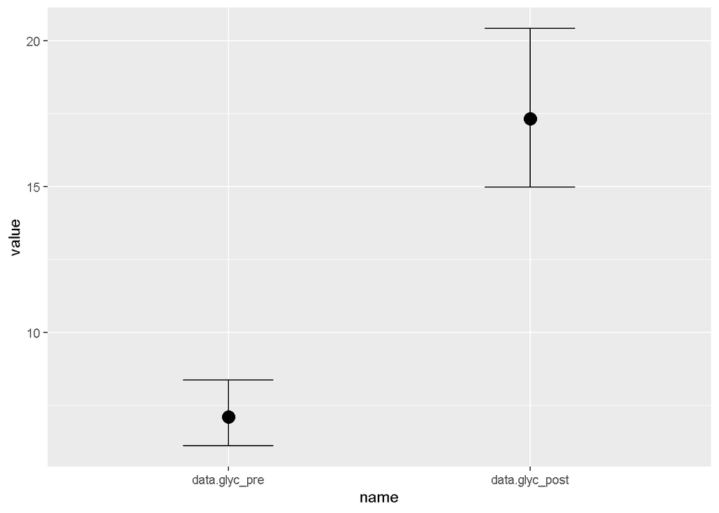

```r
conditional_effects(fit_2.2)
```

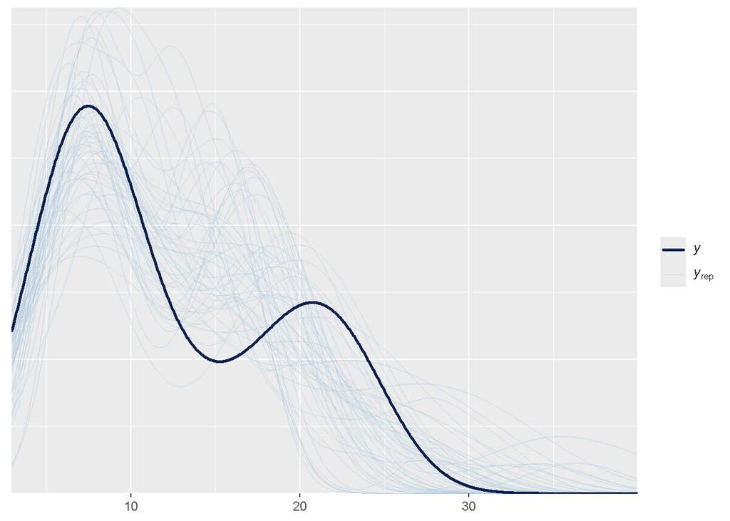

```r
pp_check(fit_2.2, ndraws = 50)
```

```r
bayes_R2(fit_2.2)
```

```
##     Estimate  Est.Error      Q2.5     Q97.5
## R2 0.6675554 0.07018519 0.4948714 0.7611275
```

```r
loo(fit_2.2, 'moment_match = TRUE')
```

```
##
## Computed from 12000 by 24 log-likelihood matrix.
##
##          Estimate  SE
## elpd_loo    -60.0 4.7
## p_loo         2.8 0.9
## looic       120.0 9.5
## ------
## MCSE of elpd_loo is 0.0.
## MCSE and ESS estimates assume MCMC draws (r_eff in [0.6, 0.9]).
##
## All Pareto k estimates are good (k < 0.7).
## See help('pareto-k-diagnostic') for details.
```

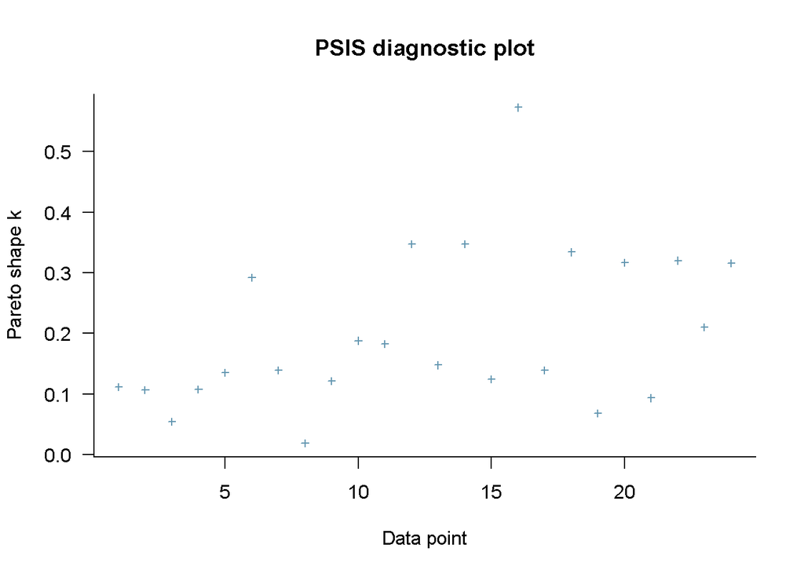

```r
plot(loo(fit_2.2, 'moment_match = TRUE'))
```

## BM2.3

Prior sensitivity analysis: Try to check the more wider prior.

```r
### Bayesian model
set.seed = 17

data2$name <- as.factor(data2$name)
data2$name <- relevel(data2$name, ref = "data.glyc_pre")

data2$value  <- as.numeric(data2$value)

bform_2.3 <- bf(value ~ 1 + name)
prior_2.3 <- c(prior(normal(0, 20), class = b))

fit_2.3 <- brm(bform_2.3,
            data = data2,
            family = brmsfamily("lognormal"),
            prior = prior_2.3,
            warmup = 2000,
            iter = 5000,
            chains = 4,
            cores = 4,
            control = list(adapt_delta = 0.95, max_treedepth = 15))
            fit_2.3 <- add_criterion(fit_2.3, "loo")

summary(fit_2.3)
```

```
##  Family: lognormal
##   Links: mu = identity; sigma = identity
## Formula: value ~ 1 + name
##    Data: data2 (Number of observations: 24)
##   Draws: 4 chains, each with iter = 5000; warmup = 2000; thin = 1;
##          total post-warmup draws = 12000
##
## Population-Level Effects:
##                    Estimate Est.Error l-95% CI u-95% CI Rhat Bulk_ESS Tail_ESS
## Intercept              1.92      0.08     1.77     2.08 1.00     9951     7276
## namedata.glyc_post     0.90      0.11     0.67     1.11 1.00    10066     7737
##
## Family Specific Parameters:
##       Estimate Est.Error l-95% CI u-95% CI Rhat Bulk_ESS Tail_ESS
## sigma     0.27      0.04     0.20     0.37 1.00     8577     6755
##
## Draws were sampled using sampling(NUTS). For each parameter, Bulk_ESS
## and Tail_ESS are effective sample size measures, and Rhat is the potential
## scale reduction factor on split chains (at convergence, Rhat = 1).
```

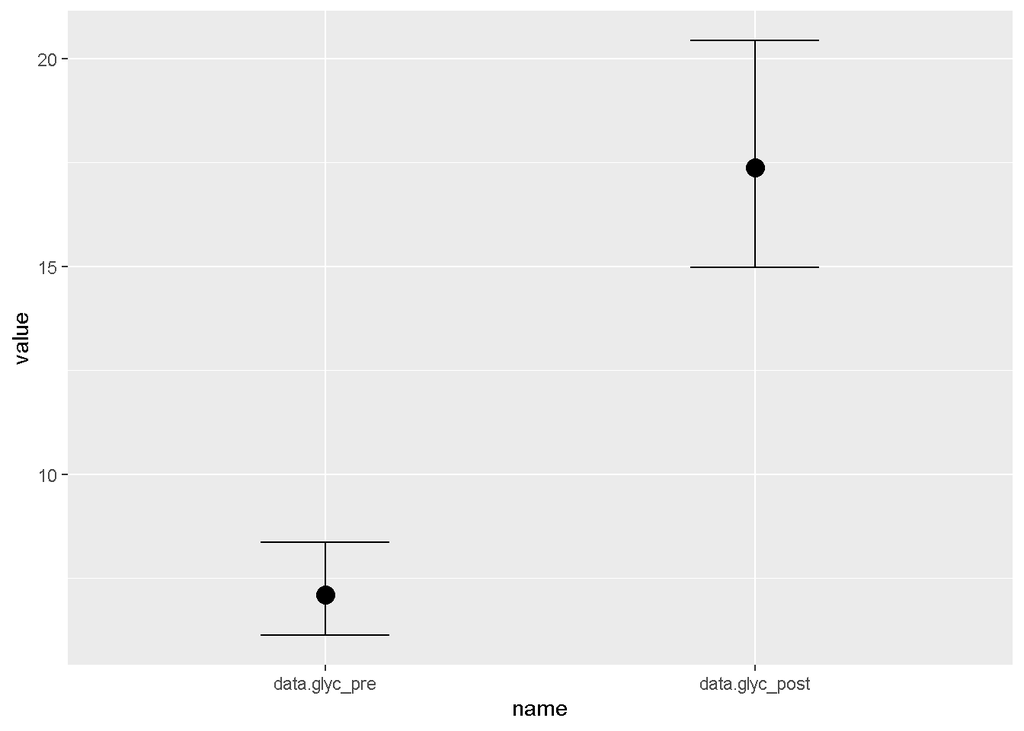

```r
conditional_effects(fit_2.3)
```

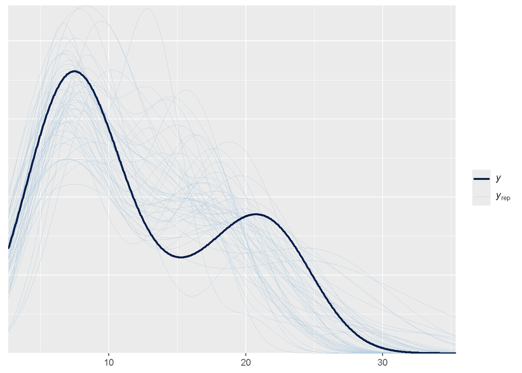

```r
pp_check(fit_2.3, ndraws = 50)
```

```r
bayes_R2(fit_2.3)
```

```
##     Estimate  Est.Error      Q2.5     Q97.5
## R2 0.6688786 0.07083719 0.4922201 0.7615262
```

```r
loo(fit_2.3, 'moment_match = TRUE')
```

```
##
## Computed from 12000 by 24 log-likelihood matrix.
##
##          Estimate  SE
## elpd_loo    -60.1 4.8
## p_loo         2.9 1.0
## looic       120.1 9.5
## ------
## MCSE of elpd_loo is 0.0.
## MCSE and ESS estimates assume MCMC draws (r_eff in [0.6, 1.0]).
##
## All Pareto k estimates are good (k < 0.7).
## See help('pareto-k-diagnostic') for details.
```

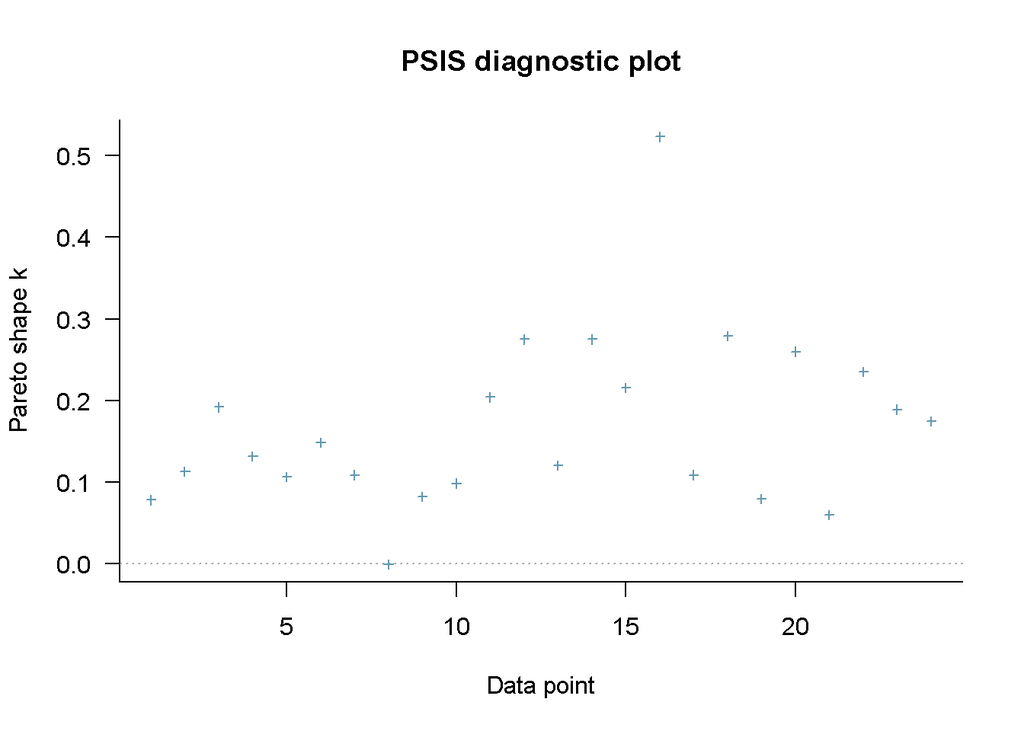

```r
plot(loo(fit_2.3, 'moment_match = TRUE'))
```

Both sensitivity analysis seem to be fine (there is no substantial change in the estimated parameters). The results are consistent with the proposed priors.

BM2 - plot the effect size (Figure 5C):

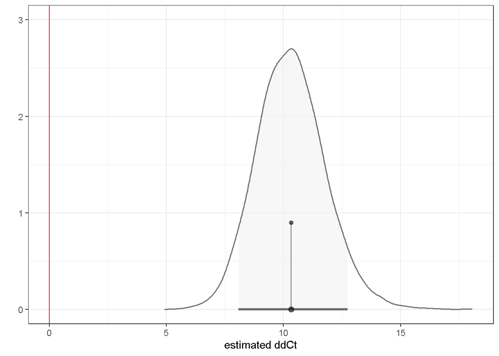

BM2 - plot the final effect size:

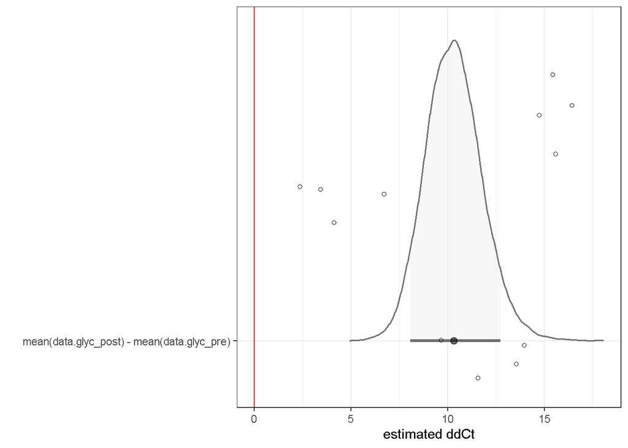

### Load data:

File *Figure_4B.txt* from the GitHub repository contains the source data (see link https://github.com/KindermannMarek/Topical-siRNA-therapy-1).

```r
library(readxl)
### Upload (!Use your own path to the data table! Load file *Figure_4B.txt* from the repository.)
qpcrinvitro <- read_excel("c:\\Users\\KindermannM\\Documents\\OneDrive_hotmail_gmail\\4_biomedical_center\\R2\\1_uochb\\Projects\\HPMA_patent\\data\\qPCR_invitro\\qpcrinvitro28102024.xlsx",
    sheet = "Sheet1")
```

Data wrangling:

```r
qpcrinvitro <-
  qpcrinvitro %>%
  mutate(dct = ct_TBP - ct_MMP9)
```

The study design incorporates a nested structure with technical replicates per experiment. This hierarchical arrangement is reflected in the multilevel model by nesting technical replicates within experiment. The model accounts for potential variability in gene expression both between experiments and among technical replicates within the experiment.

Coefficients *𝛽* are centered around 0; standard deviation (sd) of this prior was estimated as sd = 2 × standard deviation(dCt); prior(normal(0, 11)).

### BM3

random intercept for a technical replicate nested in a given experiment:

```r
### Bayesian model
set.seed = 17

qpcrinvitro$sample <- as.factor(qpcrinvitro$sample)
qpcrinvitro$ct_TBP <- as.numeric(qpcrinvitro$ct_TBP)
qpcrinvitro$ct_MMP9 <- as.numeric(qpcrinvitro$ct_MMP9)
qpcrinvitro$techrep <- as.factor(qpcrinvitro$techrep )
qpcrinvitro$exp <- as.factor(qpcrinvitro$exp )

qpcrinvitro$sample <- relevel(qpcrinvitro$sample, ref = "ctrl")


bform_3 <- bf(dct ~ 1 + sample + (1 | exp / techrep))
prior_3 <- c(prior(normal(0, 11), class = b, coef = "samplenf"),
             prior(normal(0, 11), class = b, coef = "samplesiR"))

fit_3 <- brm(bform_3,
            data = qpcrinvitro,
            family = brmsfamily("normal"),
            prior = prior_3,
            warmup = 2000,
            iter = 5000,
            chains = 4,
            cores = 4,
            control = list(adapt_delta = 0.95, max_treedepth = 15))
            fit_3 <- add_criterion(fit_3, "loo")

summary(fit_3)
```

```
##  Family: gaussian
##   Links: mu = identity; sigma = identity
## Formula: dct ~ 1 + sample + (1 | exp/techrep)
##    Data: qpcrinvitro (Number of observations: 27)
##   Draws: 4 chains, each with iter = 5000; warmup = 2000; thin = 1;
##          total post-warmup draws = 12000
##
## Group-Level Effects:
## ~exp (Number of levels: 3)
##               Estimate Est.Error l-95% CI u-95% CI Rhat Bulk_ESS Tail_ESS
## sd(Intercept)     7.51      3.82     2.91    17.49 1.00     5793     5600
##
## ~exp:techrep (Number of levels: 9)
##               Estimate Est.Error l-95% CI u-95% CI Rhat Bulk_ESS Tail_ESS
## sd(Intercept)     2.06      1.18     0.84     5.31 1.00     2991     3457
##
## Population-Level Effects:
##           Estimate Est.Error l-95% CI u-95% CI Rhat Bulk_ESS Tail_ESS
## Intercept    -5.14      3.89   -13.04     2.73 1.00     5841     6666
## samplenf      0.18      1.83    -3.37     4.11 1.00     6029     4626
## samplesiR    -3.26      1.85    -6.87     0.69 1.00     6053     4790
##
## Family Specific Parameters:
##       Estimate Est.Error l-95% CI u-95% CI Rhat Bulk_ESS Tail_ESS
## sigma     0.58      0.10     0.42     0.82 1.00     6876     6727
##
## Draws were sampled using sampling(NUTS). For each parameter, Bulk_ESS
## and Tail_ESS are effective sample size measures, and Rhat is the potential
## scale reduction factor on split chains (at convergence, Rhat = 1).
```

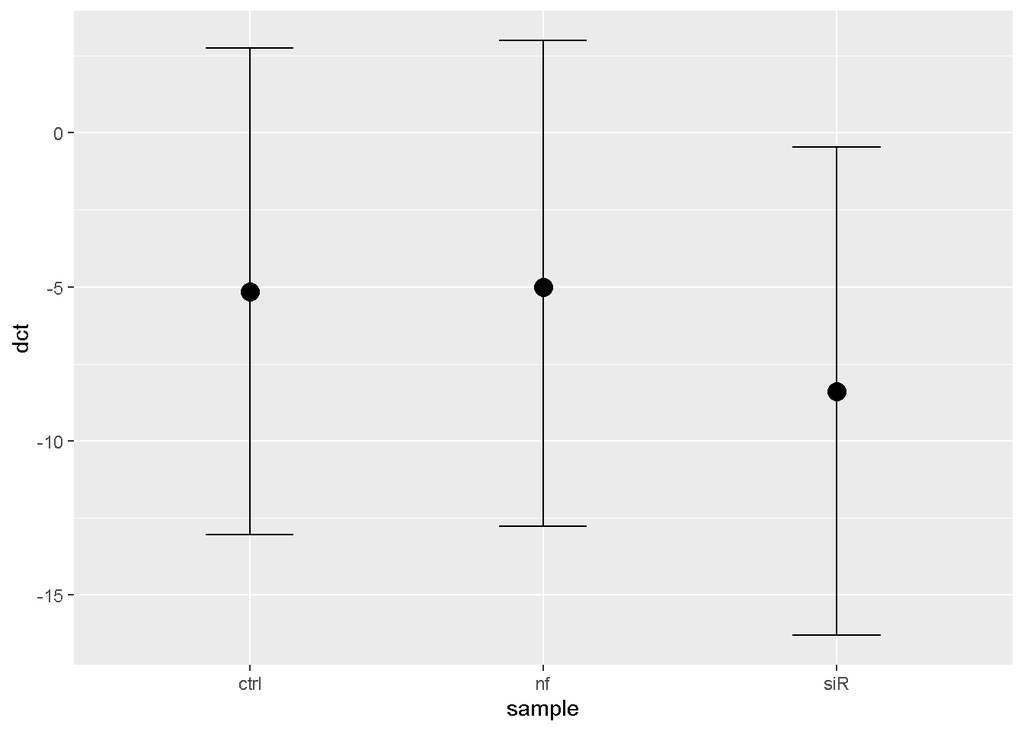

```r
conditional_effects(fit_3)
```

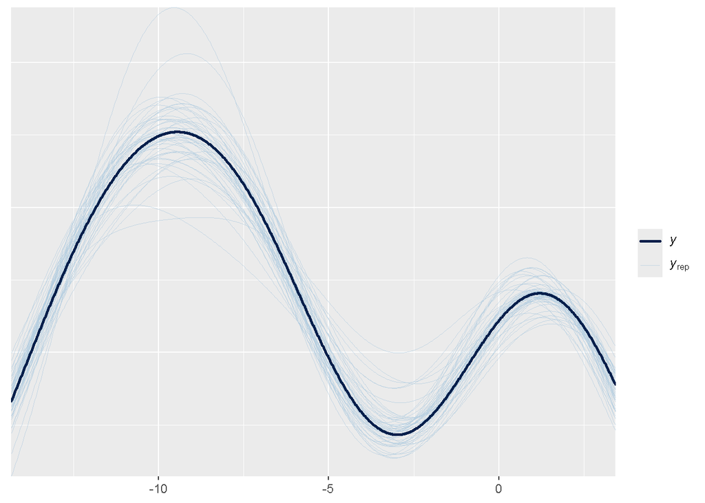

```r
pp_check(fit_3, ndraws = 50)
```

```r
bayes_R2(fit_3)
```

```
##     Estimate  Est.Error      Q2.5     Q97.5
## R2 0.9904191 0.00226786 0.9847273 0.9930774
```

```r
loo(fit_3, 'moment_match = TRUE')
```

```
##
## Computed from 12000 by 27 log-likelihood matrix.
##
##          Estimate  SE
## elpd_loo    -28.6 4.1
## p_loo         9.2 2.2
## looic        57.1 8.2
## ------
## MCSE of elpd_loo is NA.
## MCSE and ESS estimates assume MCMC draws (r_eff in [0.5, 1.1]).
##
## Pareto k diagnostic values:
##                          Count Pct.    Min. ESS
## (-Inf, 0.7]   (good)     25    92.6%   438
##    (0.7, 1]   (bad)       2     7.4%   <NA>
##    (1, Inf)   (very bad)  0     0.0%   <NA>
## See help('pareto-k-diagnostic') for details.
```

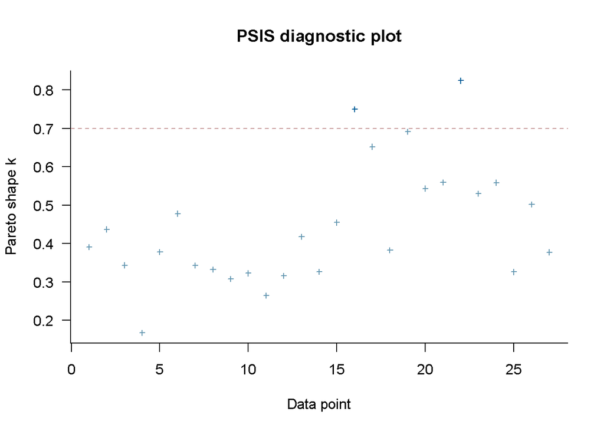

```r
plot(loo(fit_3, 'moment_match = TRUE'))
```

```r
library(emmeans)
fixef(fit_3) ### population-level (fixed) effects
```

```
##             Estimate Est.Error       Q2.5     Q97.5
## Intercept -5.1414441  3.887653 -13.042956 2.7339266
## samplenf   0.1757508  1.833950  -3.366031 4.1121016
## samplesiR -3.2569484  1.854948  -6.872209 0.6946171
```

```r
ranef(fit_3) ### group-level (random) effects
```

```
## $exp
## , , Intercept
##
##    Estimate Est.Error        Q2.5     Q97.5
## 1 -4.034993  3.901033 -11.9268125  3.743787
## 2 -2.443698  3.860783 -10.2602393  5.459966
## 3  7.049279  3.927326  -0.6481751 15.159309
##
##
## $`exp:techrep`
## , , Intercept
##
##       Estimate Est.Error      Q2.5    Q97.5
## 1_1 -0.6404483  1.695468 -4.305652 2.562420
## 1_2 -0.2821313  1.753813 -4.200053 2.900895
## 1_3  0.2111085  1.766688 -3.815860 3.402604
## 2_4  0.7496417  1.705267 -2.765192 4.144923
## 2_5  0.7450149  1.713485 -2.942252 4.043877
## 2_6 -1.8957657  1.713406 -5.592176 1.292682
## 3_7  0.1183856  1.874326 -3.040607 4.488203
## 3_8 -0.4808701  1.841890 -3.741185 3.807515
## 3_9  1.5559942  1.862433 -1.593346 5.804417
```

```r
coef(fit_3)  ### extract combined coefficients
```

```
## $exp
## , , Intercept
##
##    Estimate Est.Error       Q2.5     Q97.5
## 1 -9.176438  1.697073 -12.420339 -5.487724
## 2 -7.585142  1.707796 -10.898757 -4.114776
## 3  1.907835  1.875734  -2.476121  5.049961
##
## , , samplenf
##
##    Estimate Est.Error      Q2.5    Q97.5
## 1 0.1757508   1.83395 -3.366031 4.112102
## 2 0.1757508   1.83395 -3.366031 4.112102
## 3 0.1757508   1.83395 -3.366031 4.112102
##
## , , samplesiR
##
##    Estimate Est.Error      Q2.5     Q97.5
## 1 -3.256948  1.854948 -6.872209 0.6946171
## 2 -3.256948  1.854948 -6.872209 0.6946171
## 3 -3.256948  1.854948 -6.872209 0.6946171
##
##
## $`exp:techrep`
## , , Intercept
##
##      Estimate Est.Error      Q2.5    Q97.5
## 1_1 -5.781892  3.906270 -13.59154 2.163462
## 1_2 -5.423575  4.297934 -14.17737 3.136666
## 1_3 -4.930336  4.326031 -13.82749 3.593058
## 2_4 -4.391802  3.867992 -12.35777 3.499755
## 2_5 -4.396429  4.243232 -13.01168 4.104378
## 2_6 -7.037210  4.270784 -15.73592 1.315620
## 3_7 -5.023058  3.936653 -13.16098 2.704735
## 3_8 -5.622314  4.286033 -14.31452 2.879004
## 3_9 -3.585450  4.315747 -12.28347 5.101261
##
## , , samplenf
##
##      Estimate Est.Error      Q2.5    Q97.5
## 1_1 0.1757508   1.83395 -3.366031 4.112102
## 1_2 0.1757508   1.83395 -3.366031 4.112102
## 1_3 0.1757508   1.83395 -3.366031 4.112102
## 2_4 0.1757508   1.83395 -3.366031 4.112102
## 2_5 0.1757508   1.83395 -3.366031 4.112102
## 2_6 0.1757508   1.83395 -3.366031 4.112102
## 3_7 0.1757508   1.83395 -3.366031 4.112102
## 3_8 0.1757508   1.83395 -3.366031 4.112102
## 3_9 0.1757508   1.83395 -3.366031 4.112102
##
## , , samplesiR
##
##      Estimate Est.Error      Q2.5     Q97.5
## 1_1 -3.256948  1.854948 -6.872209 0.6946171
## 1_2 -3.256948  1.854948 -6.872209 0.6946171
## 1_3 -3.256948  1.854948 -6.872209 0.6946171
## 2_4 -3.256948  1.854948 -6.872209 0.6946171
## 2_5 -3.256948  1.854948 -6.872209 0.6946171
## 2_6 -3.256948  1.854948 -6.872209 0.6946171
## 3_7 -3.256948  1.854948 -6.872209 0.6946171
## 3_8 -3.256948  1.854948 -6.872209 0.6946171
## 3_9 -3.256948  1.854948 -6.872209 0.6946171
```